# Midterm Report

2025-03-16

## Introduction

Jargon, a startup founded by a friend about a year ago, introduced an innovative language learning Chrome extension (https://chromewebstore.google.com/detail/jargon/gghkanaadhldgmknmgggdgfaonhpppoj). I’ve recently joined the team as the new tech lead to spearhead technology initiatives.

Jargon enhances the browsing experience by underlining text on websites and generating language practice questions from these selections, catering to users’ active engagement. This tool is designed for students seeking to bolster their language studies through daily practice.

Despite being in the market for eight months, Jargon only has 100+ downloads on the Chrome extension store. Jargon faces challenges with user adoption and potential market and product issues. To address these challenges, I have decided to begin by analyzing the company’s database to gain insights that could drive improvements in our product and strategies. The primary question I aim to address is: What key factors influence user engagement and sustained usage of Jargon?

Github repo link: https://github.com/cyn900/JSC370-project

## Methods

The original developers of Jargon designed a database to track real-life usage and store relevant information on Supabase. I downloaded five CSV files (profiles, words, questions, levels, and websites) from Supabase on March 16, 2025 for analysis.

The 1st CSV, profiles, contains 92 user profile information that includes the current settings for each user profile. Each user is represented by a unique ID, which serves as the primary key in this dataset. This dataset includes user_id, level (current proficiency level), paused (whether paused on Chrome or not), chrome_notifs (whether Chrome notifications are open), language (the current language chosen), last_question_time, week_streak, daily_streak, daily_progress, daily_goal, density (density of the questions displayed on the website), highlightStyle (underline or highlight), and bonus_points. The bonus points column was designed for a competition in which users could earn bonus points by following on Instagram, joining Discord, commenting, and participating in activities to spread the word on the Chrome extension store. Note that the username was originally stored in this dataset, but I manually deleted the name column to protect users’ privacy.

The 2nd CSV, websites, contains the websites users chose to block Jargon on. It includes user_id and website (url). The combination of these two serves as the primary key. There are 27 entries in total.

The 3rd CSV, levels, contains all records of users’ chosen languages to study. It includes user_id, language, and level. The combination of these three serves as the primary key. There are 117 entries in total.

The 4th CSV, questions, contains all questions generated by Jargon. It includes created_at, user_id, sentence, word, question_id, language, original_sentence, answered_at (time when the user answers), chosen_option, and user_rating. The question_id serves as the primary key. There are 2442 entries in total.

The 5th CSV, “words,” contains the correct words for all the questions users have answered. It includes created_at, word, language, user_id, translation, and status. There are 1594 entries in total.

My primary objective is to identify patterns in user behavior.I have enriched the profile datasets with additional information, including generated_questions (the number of questions generated) and answered_questions (answered by each user), enhanced_profiles (the number of websites they have blocked), and distinct_levels (the variety of levels they have attempted).

Furthermore, regarding highlightStyle, there are only two options: highlight or underline. Therefore, I have converted it to a boolean format where 1 represents highlight and 0 represents underline.

I am also interested in conducting some Natural Language Processing (NLP) analysis. Although Jargon supports multiple languages including Chinese, Spanish, and Tamil, I currently intend to narrow my focus to English content for a more straightforward analysis. This will specifically involve English content such as GRE Vocabulary, SAT Vocabulary, GlizzyTalk and TikTok Slang. The dataset containing English questions comprises 624 entries.

## Preliminary Results

### User Profile

Understanding user engagement is crucial for optimizing user experience and enhancing platform functionality. First, it is important to understand how user is using the product.

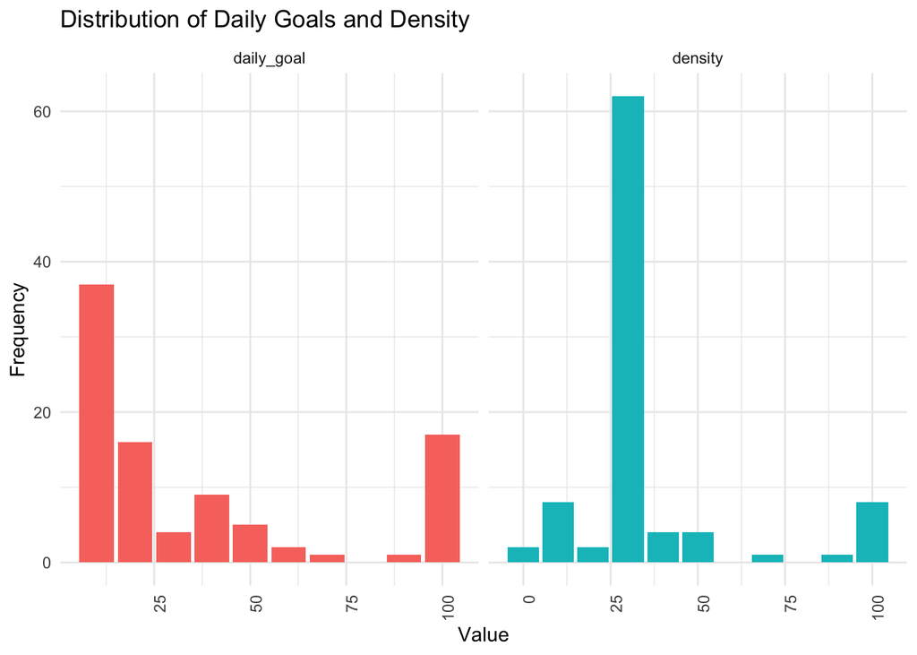

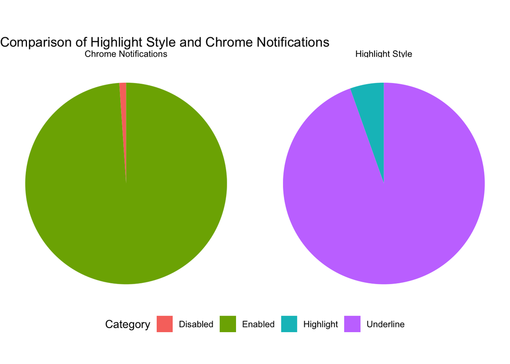

Only a small portion of people disable the notification.

The pie chart depicts the distribution of highlight styles among users, revealing a strong preference for the Underline style compared to Highlight. Notably, Highlight is a relatively new feature introduced based on active user suggestions, while “Underline” remains the default option. This discrepancy in preference may be due to users not being fully aware of the new Highlight option.

I also created key metrics of user interactions within our platform, which include Generated Questions, Answered Questions, Blocked Sites, and Levels Attempted. These metrics are instrumental in identifying user behaviors, gauging the effectiveness of the content, and detecting areas that may require improvements or additional support.

Descriptive Statistics for Key Variables

| Metric | Mean | Median | Maximum | Minimum |
| --- | --- | --- | --- | --- |
| Generated Questions | 26.54 | 5.5 | 647 | 0 |
| Answered Questions | 17.33 | 4.0 | 267 | 0 |
| Blocked Sites | 0.29 | 0.0 | 7 | 0 |
| Levels Attempted | 1.17 | 1.0 | 4 | 0 |

These statistics illustrate a varied level of engagement across different metrics, with notable differences between mean and median values for several metrics suggesting skewed distributions. Such insights can guide targeted strategies to enhance user participation and address areas with lower engagement.

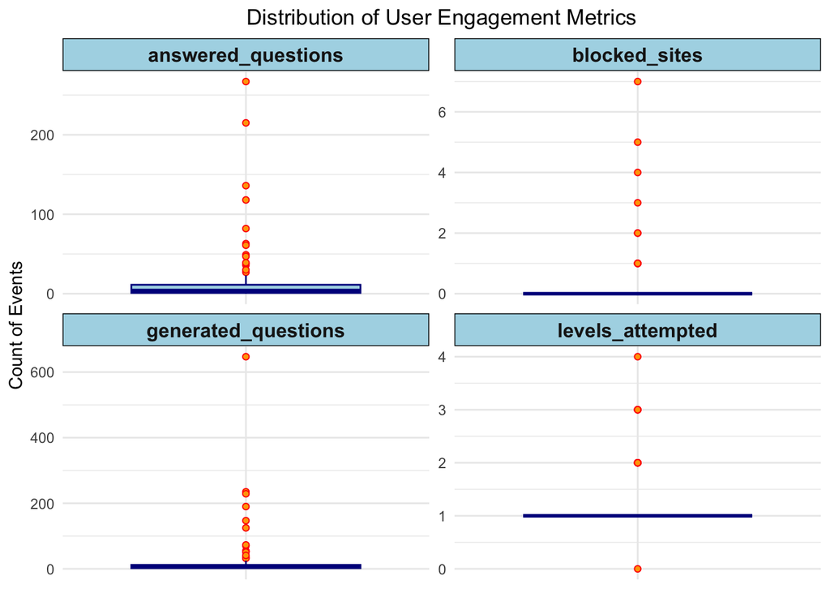

These box plots supported our finding from the statistics above, highlighting that while a majority of users engage at lower levels across various metrics, there are notable exceptions where some users show exceptionally high engagement.

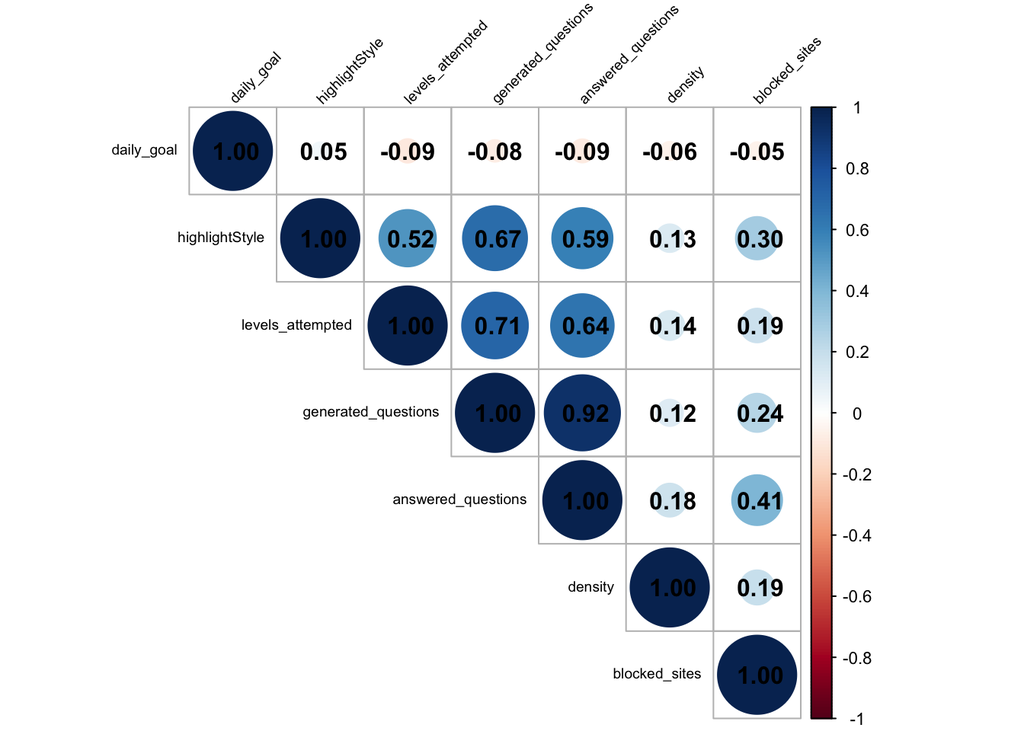

The correlation matrix illustrates key relationships between user engagement metrics. Notably, “Generated Questions” and “Answered Questions” show a very strong correlation (0.92), indicating that users who generate more questions tend to answer more as well. “Levels Attempted” is significantly correlated with both “Generated Questions” (0.71) and “Answered Questions” (0.64), suggesting that more active users engage across multiple dimensions of the platform. The “HighlightStyle” variable shows moderate correlations with “Levels Attempted” (0.52) and “Generated Questions” (0.67), indicating that the choice of highlight style might be linked to higher user activity. Other metrics such as “Daily Goal,” “Density,” and “Blocked Sites” show weaker correlations with user activity metrics, suggesting less direct interaction with these elements.

### Question Generation

Answering questions while browsing on Chrome is at the core of our product. It is crucial for us to understand not only what content users are engaging with but also their experiences in generating and answering questions. This understanding helps us to continuously improve the relevance and usability of our content, ensuring that the platform effectively meets user needs and enhances their browsing experience.

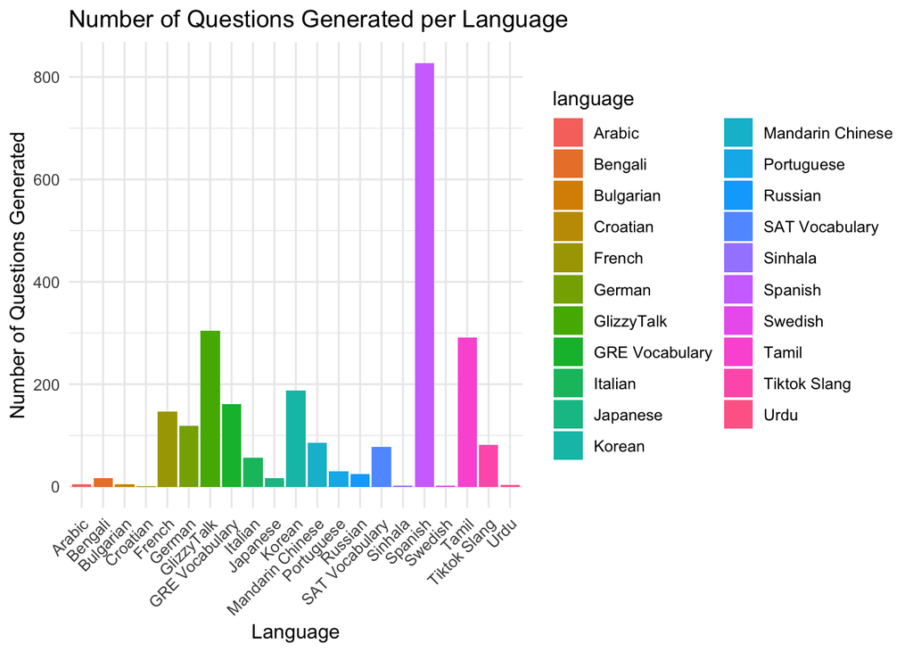

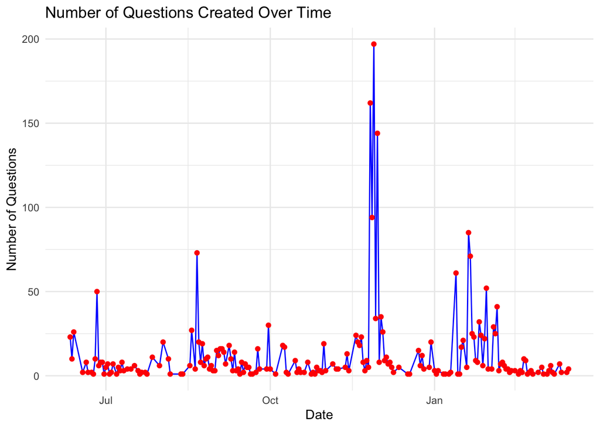

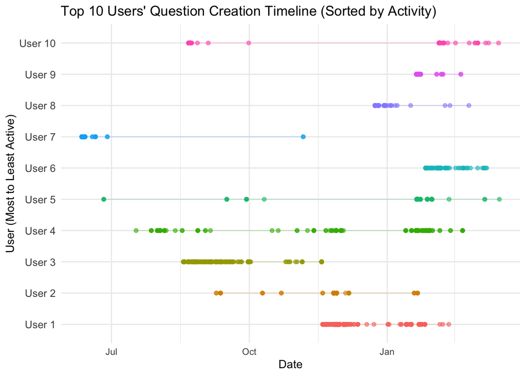

The graph visualizes the question creation timelines of the top 10 most active users, sorted from most to least active. All users are sporadic in their activity, with noticeable gaps between their question submissions.

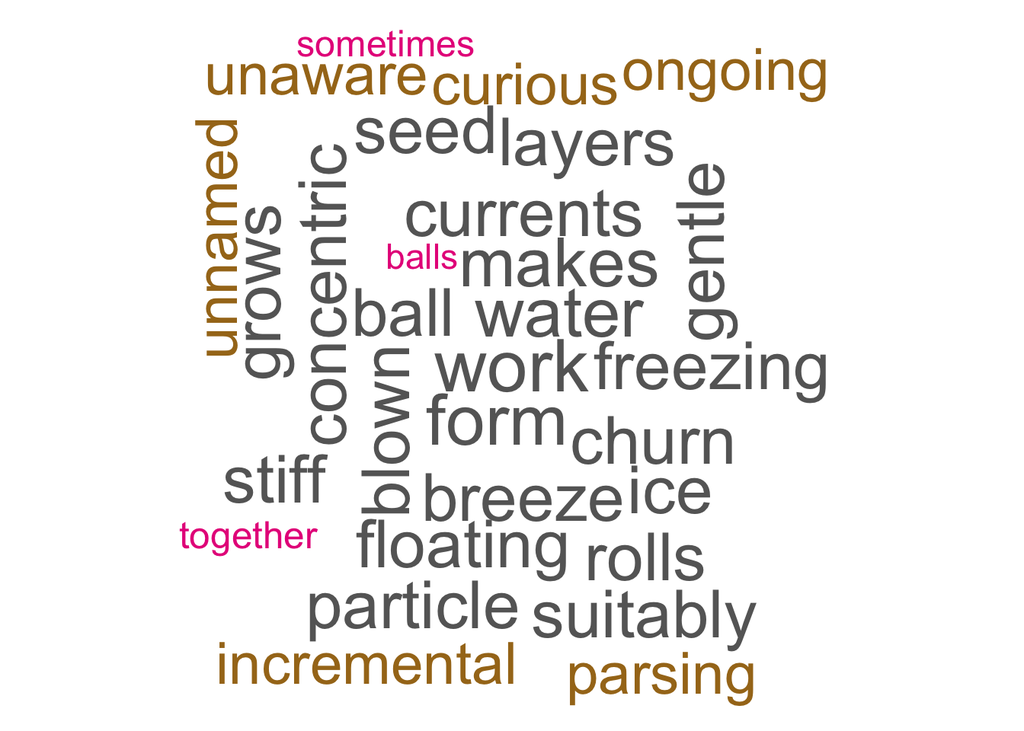

Using the word cloud, we’ve observed that many words appear with the same frequency. To derive more nuanced insights into common themes and understand the type of content people engage with on Jargon, it would be advantageous to implement a more sophisticated clustering model. This approach will help us identify underlying patterns in the data, enhancing our ability to tailor and optimize the content effectively.

## Summary

From my initial exploration, I found that despite having 92 users on record, the product is not being used as consistently as expected. While only a small portion of users have disabled notifications, which may contribute to lower engagement, the broader issue seems to be that users are not integrating Jargon into their daily browsing as originally envisioned. The initial assumption was that users would engage with language learning passively while browsing daily, but the data suggests otherwise.

### Next Step

To better understand why users are not consistently using Jargon, I will conduct a structured analysis using data-driven modeling techniques and natural language processing (NLP) to extract insights. The key focus areas will be content analysis and user segmentation, with specific methods to handle multilingual data.

1. Content Analysis: Identifying What Users Engage With

This analysis will investigate the types of content users interact with when using Jargon to determine if specific topics, websites, or language levels impact engagement.

Steps & Methods

```
1.  Data Preprocessing & Cleaning

•   Detect and classify languages using cld2 or textcat.
•   Normalize and clean text data by applying language-specific preprocessing:
•   English, Spanish, French: Use spaCy or nltk for tokenization and stopword removal.
•   Chinese: Use jiebaR for tokenization.
•   Remove punctuation, special characters, and unnecessary symbols.

2.  Topic Modeling
•   Apply Latent Dirichlet Allocation (LDA) to extract common themes from the articles and webpages users engage with.
•   Use TF-IDF (Term Frequency-Inverse Document Frequency) to identify key terms in different languages.

3.  Sentiment & Readability Analysis

•   Perform sentiment analysis to assess whether positive or negative content affects engagement:
•   English: Use syuzhet for sentiment scoring.
•   Chinese: Use SnowNLP for sentiment classification.
•   Calculate readability scores (e.g., Flesch-Kincaid for English) to determine if more complex content affects engagement levels.

4.  Correlation with Engagement

•   Compare extracted themes, sentiment scores, and readability scores against:
•   Number of questions generated/answered
```

⸻

2. Segmentation of Active vs. Inactive Users

The goal is to identify behavioral differences between highly engaged users and those who rarely use Jargon.

Steps & Methods

```
1.  User Segmentation Using Clustering

•   Apply K-Means Clustering or Hierarchical Clustering to group users into different engagement levels.
•   Identify behavioral patterns within each segment (e.g., whether highly active users prefer certain content or interact differently).

3.  Predictive Modeling for Engagement

•   Train a Random Forest Classifier or Logistic Regression Model to predict whether a user is likely to become an active or inactive user based on their behavior.
```

⸻

Final Goals

By conducting these analyses, I aim to:

```
•   Identify patterns in content consumption to understand what types of material encourage engagement.
•   Determine key engagement drivers by segmenting users based on their behavior.
•   Improve Jargon’s user experience by refining recommendations and adapting learning methods to fit actual usage patterns.
```

This structured approach will provide actionable insights to enhance Jargon’s effectiveness and user retention.